# 20200925

Takala

3日間に渡って開催された都市・交通理論ドクター若手勉強会， 非常に良い機会であった．

本日はバタバタしており，兄弟子の発表に途中参加してしまったのだが， Zoomに接続してヘッドフォンを付けた瞬間 「ここらへんは酒井君が詳しいんじゃないですか？？」 なんて話題になっており肝を冷やした．

実際，動的交通量配分モデルの解の一意性に関する話題で， これにスパっと粋に答えられなかった己が恥ずかしい． 修行が足りない．反省．（それにしても弊ラボのOBの方々はみなさん分野のトップランナーであると改めて感じた）

余談だが，先ほどの兄弟子に話を振られしどろもどろした解答をした直後， さびれた私のHPのトラフィックが急増した．

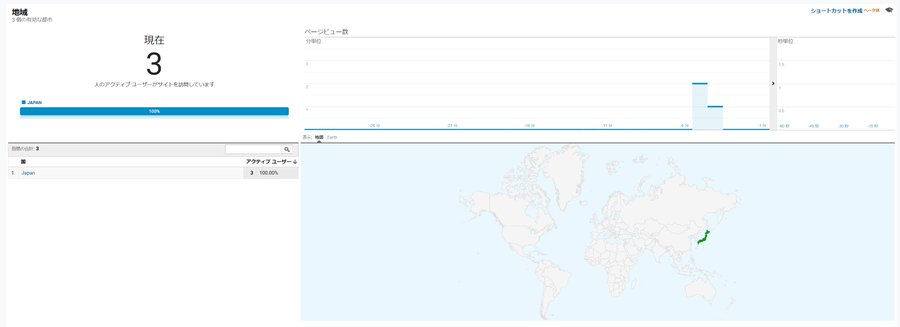

image

「誰やこいつ」と思われたのだろう． リアルタイムで3人に見られることなんてまずないので，なかな貴重な一瞬．